# 01. Bitbank Fee MM戦略 - データ探索

## 目的

BitbankのMaker Fee（-2bps）狙いの高頻度MM戦略を構築するための初期データ探索を行う。

## 分析内容

1. 各通貨ペアの約定量（Volume）の比較
2. スプレッドの分析
3. 板の厚み・流動性の分析
4. 最適な通貨ペアの選定

```python
# 基本セットアップ
from etr.auto_import import *
HTML(full_width_display)
```

```python
# 追加ライブラリ
from etr.data.data_loader import load_data
import warnings
warnings.filterwarnings('ignore')
```

## 1. 各通貨ペアの約定量分析

まず各通貨ペアの日次約定量（JPY建て）を比較して、どの通貨ペアがMM戦略に適しているか確認する。

```python
# 分析対象の通貨ペアとデータ期間
symbols = ['BTCJPY', 'ETHJPY', 'XRPJPY', 'LTCJPY', 'DOGEJPY', 'BCCJPY', 'SOLJPY']
venue = 'bitbank'

# サンプル期間（直近1週間）
dates = pd.date_range('2026-01-20', '2026-01-26')

print(f"分析対象: {symbols}")
print(f"期間: {dates[0].date()} ~ {dates[-1].date()}")
```

```
分析対象: ['BTCJPY', 'ETHJPY', 'XRPJPY', 'LTCJPY', 'DOGEJPY', 'BCCJPY', 'SOLJPY']
期間: 2026-01-20 ~ 2026-01-26
```

```python
# 各通貨ペアの日次約定量を取得
volume_data = []

for sym in symbols:
    for date in dates:
        try:
            df = load_data(date.strftime('%Y-%m-%d'), 'MarketTrade', venue, sym)
            if df is not None and len(df) > 0:
                # JPY建て約定額
                total_volume_jpy = (df['price'] * df['amount']).sum()
                trade_count = len(df)
                volume_data.append({
                    'symbol': sym,
                    'date': date.date(),
                    'volume_jpy': total_volume_jpy,
                    'trade_count': trade_count
                })
        except Exception as e:
            pass

volume_df = pd.DataFrame(volume_data)
print(f"取得データ件数: {len(volume_df)}")
```

[output not shown]

[output not shown]

[output not shown]

[output not shown]

[output not shown]

[output not shown]

[output not shown]

[output not shown]

[output not shown]

[output not shown]

[output not shown]

[output not shown]

[output not shown]

[output not shown]

[output not shown]

[output not shown]

[output not shown]

[output not shown]

[output not shown]

[output not shown]

[output not shown]

[output not shown]

[output not shown]

[output not shown]

[output not shown]

[output not shown]

[output not shown]

[output not shown]

[output not shown]

[output not shown]

[output not shown]

[output not shown]

[output not shown]

[output not shown]

[output not shown]

[output not shown]

[output not shown]

[output not shown]

[output not shown]

[output not shown]

[output not shown]

[output not shown]

```
取得データ件数: 42
```

```python
# 通貨ペア別の平均日次約定量
volume_summary = volume_df.groupby('symbol').agg({
    'volume_jpy': ['mean', 'sum'],
    'trade_count': ['mean', 'sum']
}).round(0)

volume_summary.columns = ['avg_daily_volume_jpy', 'total_volume_jpy', 'avg_daily_trades', 'total_trades']
volume_summary = volume_summary.sort_values('avg_daily_volume_jpy', ascending=False)

# 見やすく表示
display_df = volume_summary.copy()
display_df['avg_daily_volume_jpy'] = display_df['avg_daily_volume_jpy'].apply(lambda x: f"¥{x:,.0f}")
display_df['total_volume_jpy'] = display_df['total_volume_jpy'].apply(lambda x: f"¥{x:,.0f}")
display_df['avg_daily_trades'] = display_df['avg_daily_trades'].apply(lambda x: f"{x:,.0f}")
display_df['total_trades'] = display_df['total_trades'].apply(lambda x: f"{x:,.0f}")

print("通貨ペア別 約定量サマリー（1週間）")
display(display_df)
```

```
通貨ペア別 約定量サマリー（1週間）
```

| symbol | avg_daily_volume_jpy | total_volume_jpy | avg_daily_trades | total_trades |
| --- | --- | --- | --- | --- |
| BTCJPY | ¥2,528,745,620 | ¥17,701,219,337 | 11,406 | 79,845 |
| XRPJPY | ¥2,337,704,874 | ¥16,363,934,121 | 20,829 | 145,802 |
| ETHJPY | ¥1,573,849,263 | ¥11,016,944,839 | 8,326 | 58,280 |
| DOGEJPY | ¥408,511,169 | ¥2,859,578,186 | 4,268 | 29,874 |
| SOLJPY | ¥337,325,738 | ¥2,361,280,163 | 3,805 | 26,632 |
| LTCJPY | ¥56,797,849 | ¥397,584,944 | 1,191 | 8,337 |

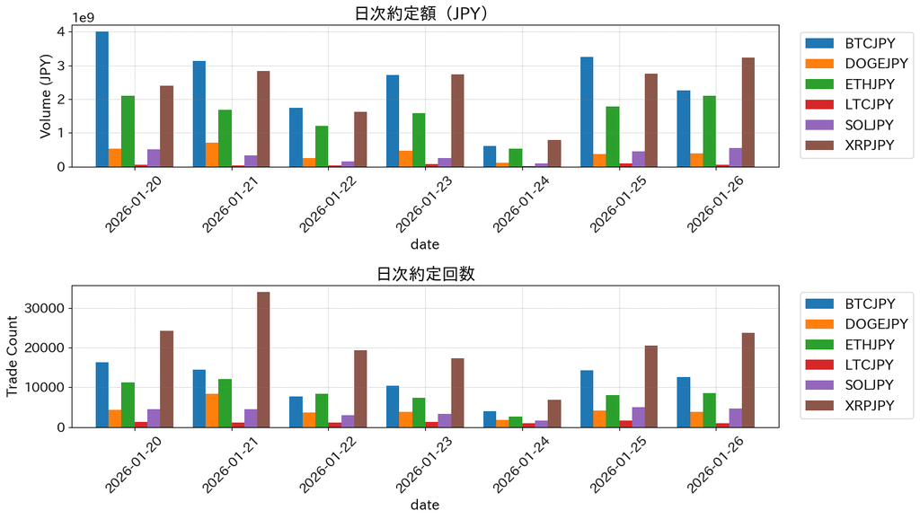

```python
# 日次約定量の可視化
fig, axes = plt.subplots(2, 1, figsize=(14, 8))

# 約定額
pivot_volume = volume_df.pivot(index='date', columns='symbol', values='volume_jpy')
pivot_volume.plot(kind='bar', ax=axes[0], width=0.8)
axes[0].set_title('日次約定額（JPY）')
axes[0].set_ylabel('Volume (JPY)')
axes[0].legend(bbox_to_anchor=(1.02, 1), loc='upper left')
axes[0].tick_params(axis='x', rotation=45)

# 約定回数
pivot_trades = volume_df.pivot(index='date', columns='symbol', values='trade_count')
pivot_trades.plot(kind='bar', ax=axes[1], width=0.8)
axes[1].set_title('日次約定回数')
axes[1].set_ylabel('Trade Count')
axes[1].legend(bbox_to_anchor=(1.02, 1), loc='upper left')
axes[1].tick_params(axis='x', rotation=45)

plt.tight_layout()
plt.show()
```

## 2. スプレッド分析

MM戦略ではスプレッドが重要。各通貨ペアのスプレッド（bps）を分析する。

```python
# 1日分のRateデータでスプレッド分析
sample_date = '2026-01-25'
spread_data = []

for sym in symbols:
    try:
        df = load_data(sample_date, 'Rate', venue, sym)
        if df is not None and len(df) > 0:
            # スプレッドをbpsで計算 (カラム名: best_bid, best_ask, mid_price)
            df['spread_bps'] = (df['best_ask'] - df['best_bid']) / df['mid_price'] * 10000

            spread_data.append({
                'symbol': sym,
                'spread_mean_bps': df['spread_bps'].mean(),
                'spread_median_bps': df['spread_bps'].median(),
                'spread_std_bps': df['spread_bps'].std(),
                'spread_min_bps': df['spread_bps'].min(),
                'spread_max_bps': df['spread_bps'].max(),
                'spread_p25_bps': df['spread_bps'].quantile(0.25),
                'spread_p75_bps': df['spread_bps'].quantile(0.75),
                'sample_count': len(df)
            })
    except Exception as e:
        print(f"{sym}: {e}")

spread_df = pd.DataFrame(spread_data)
if len(spread_df) > 0:
    spread_df = spread_df.sort_values('spread_mean_bps')
    print(f"スプレッド分析（{sample_date}）")
    display(spread_df.round(2))
else:
    print("スプレッドデータがありません")
```

[output not shown]

[output not shown]

[output not shown]

[output not shown]

[output not shown]

[output not shown]

```
スプレッド分析（2026-01-25）
```

|  | symbol | spread_mean_bps | spread_median_bps | spread_std_bps | spread_min_bps | spread_max_bps | spread_p25_bps | spread_p75_bps | sample_count |
| --- | --- | --- | --- | --- | --- | --- | --- | --- | --- |
| 2 | XRPJPY | 0.92 | 0.52 | 1.21 | 0.03 | 44.01 | 0.07 | 1.28 | 23257 |
| 0 | BTCJPY | 0.99 | 0.39 | 1.43 | 0.00 | 36.30 | 0.00 | 1.54 | 7067 |
| 1 | ETHJPY | 1.20 | 0.79 | 1.41 | 0.02 | 15.24 | 0.04 | 1.81 | 26429 |
| 4 | DOGEJPY | 2.52 | 2.13 | 1.95 | 0.52 | 31.82 | 1.05 | 3.26 | 34942 |
| 5 | SOLJPY | 2.79 | 2.14 | 2.86 | 0.05 | 56.74 | 0.80 | 3.69 | 38606 |
| 3 | LTCJPY | 14.50 | 12.84 | 10.29 | 0.09 | 92.25 | 6.91 | 19.60 | 113057 |

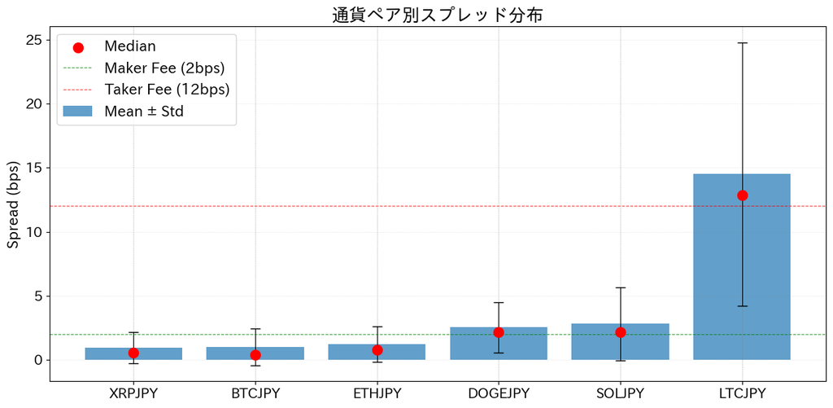

```python
# スプレッドの可視化
if len(spread_df) > 0:
    fig, ax = plt.subplots(figsize=(12, 6))

    x = range(len(spread_df))
    ax.bar(x, spread_df['spread_mean_bps'], yerr=spread_df['spread_std_bps'],
           capsize=5, alpha=0.7, label='Mean ± Std')
    ax.scatter(x, spread_df['spread_median_bps'], color='red', s=100, zorder=5, label='Median')

    # Maker fee（-2bps）とTaker fee（12bps）のライン
    ax.axhline(y=2, color='green', linestyle='--', alpha=0.7, label='Maker Fee (2bps)')
    ax.axhline(y=12, color='red', linestyle='--', alpha=0.7, label='Taker Fee (12bps)')

    ax.set_xticks(x)
    ax.set_xticklabels(spread_df['symbol'])
    ax.set_ylabel('Spread (bps)')
    ax.set_title('通貨ペア別スプレッド分布')
    ax.legend()
    ax.grid(axis='y', alpha=0.3)

    plt.tight_layout()
    plt.show()
```

## 3. 板の厚み分析

MM戦略では板の厚み（流動性）も重要。Best Bid/AskのサイズとBook深さを確認する。

```python
# MarketBookデータで板の厚みを分析
book_data = []

for sym in symbols:
    try:
        df = load_data(sample_date, 'MarketBook', venue, sym)
        if df is not None and len(df) > 0:
            # Best Bid/Ask のサイズを取得 (bids/asksは[price, size]のnumpy array)
            best_bid_sizes = []
            best_ask_sizes = []

            for _, row in df.iterrows():
                if 'bids' in df.columns and len(row['bids']) > 0:
                    best_bid_sizes.append(row['bids'][0][1])  # [price, size]
                if 'asks' in df.columns and len(row['asks']) > 0:
                    best_ask_sizes.append(row['asks'][0][1])

            if best_bid_sizes and best_ask_sizes:
                book_data.append({
                    'symbol': sym,
                    'best_bid_size_mean': np.mean(best_bid_sizes),
                    'best_ask_size_mean': np.mean(best_ask_sizes),
                    'best_bid_size_median': np.median(best_bid_sizes),
                    'best_ask_size_median': np.median(best_ask_sizes),
                    'sample_count': len(df)
                })
    except Exception as e:
        print(f"{sym}: {e}")

if book_data:
    book_df = pd.DataFrame(book_data)
    print(f"板の厚み分析（{sample_date}）")
    display(book_df.round(4))
else:
    print("MarketBookデータの取得に問題がありました")
```

[output not shown]

[output not shown]

[output not shown]

[output not shown]

[output not shown]

[output not shown]

```
板の厚み分析（2026-01-25）
```

|  | symbol | best_bid_size_mean | best_ask_size_mean | best_bid_size_median | best_ask_size_median | sample_count |
| --- | --- | --- | --- | --- | --- | --- |
| 0 | BTCJPY | 0.3321 | 0.6053 | 0.1335 | 0.3612 | 245172 |
| 1 | ETHJPY | 13.4710 | 7.4008 | 2.7269 | 1.8600 | 240935 |
| 2 | XRPJPY | 21751.3463 | 20588.9985 | 2200.0000 | 3957.4229 | 244469 |
| 3 | LTCJPY | 27.6701 | 16.4387 | 6.0000 | 6.0000 | 203849 |
| 4 | DOGEJPY | 88159.5485 | 75094.8215 | 11211.0740 | 14530.9999 | 192069 |
| 5 | SOLJPY | 32.1413 | 42.2205 | 8.2215 | 16.3820 | 224468 |

```python
# MarketBookデータの構造を確認
sample_sym = 'BTCJPY'
df = load_data(sample_date, 'MarketBook', venue, sample_sym)
if df is not None and len(df) > 0:
    print(f"MarketBook columns: {df.columns.tolist()}")
    print(f"\nサンプル行:")
    display(df.head(3))
```

[output not shown]

```
MarketBook columns: ['timestamp', 'market_created_timestamp', 'sym', 'venue', 'category', 'bids', 'asks', 'universal_id', 'misc']

サンプル行:
```

|  | timestamp | market_created_timestamp | sym | venue | category | bids | asks | universal_id | misc |
| --- | --- | --- | --- | --- | --- | --- | --- | --- | --- |
| 0 | 2026-01-25 00:00:00.116378+00:00 | 2026-01-25 00:00:00.076000+00:00 | BTCJPY | bitbank | None | [[13918000.0, 0.0181], [13917425.0, 0.0001], [... | [[13918001.0, 1.8597], [13918632.0, 0.0004], [... | 51714a948b0d483b92f459c0ef0fc6df | ['diff', 30209808695] |
| 1 | 2026-01-25 00:00:00.792186+00:00 | 2026-01-25 00:00:00.783000+00:00 | BTCJPY | bitbank | None | [[13918000.0, 0.0181], [13917425.0, 0.0001], [... | [[13918001.0, 1.8601], [13918649.0, 0.03], [13... | 92779c964ac3498a9d85394190f01dc4 | ['diff', 30209808791] |
| 2 | 2026-01-25 00:00:01.138195+00:00 | 2026-01-25 00:00:01.141000+00:00 | BTCJPY | bitbank | None | [[13918000.0, 0.0181], [13917425.0, 0.0001], [... | [[13918001.0, 1.8578], [13918649.0, 0.03], [13... | 1e3b41ec3a05475cb17d5f118f4615ea | ['diff', 30209808843] |

## 4. 時間帯別の約定量分析

時間帯によって流動性が変わるので、どの時間帯が取引しやすいか確認する。

[output not shown]

[output not shown]

[output not shown]

[output not shown]

[output not shown]

[output not shown]

[output not shown]

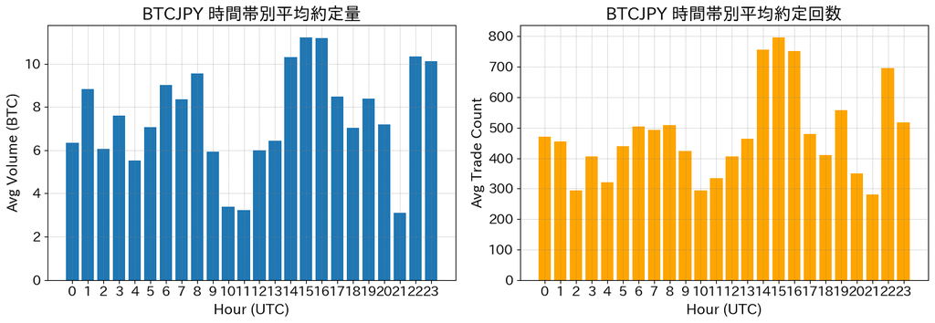

```python
# BTCJPYの時間帯別約定量分析
target_sym = 'BTCJPY'
hourly_data = []

for date in dates:
    try:
        df = load_data(date.strftime('%Y-%m-%d'), 'MarketTrade', venue, target_sym)
        if df is not None and len(df) > 0:
            df['hour'] = pd.to_datetime(df['timestamp']).dt.hour
            hourly = df.groupby('hour').agg({
                'amount': 'sum',
                'price': 'count'
            }).rename(columns={'price': 'trade_count'})
            hourly['date'] = date.date()
            hourly_data.append(hourly.reset_index())
    except Exception as e:
        pass

if hourly_data:
    hourly_df = pd.concat(hourly_data)
    hourly_summary = hourly_df.groupby('hour').agg({
        'amount': 'mean',
        'trade_count': 'mean'
    }).round(2)

    fig, axes = plt.subplots(1, 2, figsize=(14, 5))

    axes[0].bar(hourly_summary.index, hourly_summary['amount'])
    axes[0].set_xlabel('Hour (UTC)')
    axes[0].set_ylabel('Avg Volume (BTC)')
    axes[0].set_title(f'{target_sym} 時間帯別平均約定量')
    axes[0].set_xticks(range(24))

    axes[1].bar(hourly_summary.index, hourly_summary['trade_count'], color='orange')
    axes[1].set_xlabel('Hour (UTC)')
    axes[1].set_ylabel('Avg Trade Count')
    axes[1].set_title(f'{target_sym} 時間帯別平均約定回数')
    axes[1].set_xticks(range(24))

    plt.tight_layout()
    plt.show()
```

## 5. 約定サイドの分析

Buy/Sellの比率やトレンドを確認する。これはMM戦略でのポジションリスク管理に重要。

[output not shown]

[output not shown]

[output not shown]

[output not shown]

[output not shown]

[output not shown]

[output not shown]

[output not shown]

[output not shown]

[output not shown]

[output not shown]

[output not shown]

[output not shown]

[output not shown]

[output not shown]

[output not shown]

[output not shown]

[output not shown]

[output not shown]

[output not shown]

[output not shown]

[output not shown]

[output not shown]

[output not shown]

[output not shown]

[output not shown]

[output not shown]

[output not shown]

[output not shown]

[output not shown]

[output not shown]

[output not shown]

[output not shown]

[output not shown]

[output not shown]

[output not shown]

[output not shown]

[output not shown]

[output not shown]

[output not shown]

[output not shown]

[output not shown]

```
約定サイド比率分析（1週間）
```

|  | symbol | buy_ratio | sell_ratio | net_buy_ratio |
| --- | --- | --- | --- | --- |
| 0 | BTCJPY | 50 | 50 | 0 |
| 1 | ETHJPY | 50 | 50 | 0 |
| 2 | XRPJPY | 50 | 50 | 0 |
| 3 | LTCJPY | 50 | 50 | 0 |
| 4 | DOGEJPY | 50 | 50 | 0 |
| 5 | SOLJPY | 50 | 50 | 0 |

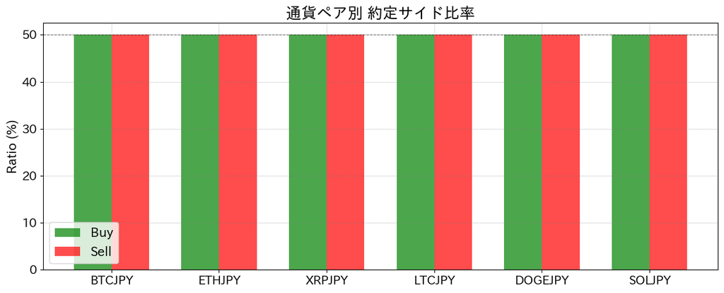

```python
# 約定サイドの分析
side_data = []

for sym in symbols:
    sym_trades = []
    for date in dates:
        try:
            df = load_data(date.strftime('%Y-%m-%d'), 'MarketTrade', venue, sym)
            if df is not None and len(df) > 0:
                sym_trades.append(df)
        except:
            pass

    if sym_trades:
        all_trades = pd.concat(sym_trades)
        if 'side' in all_trades.columns:
            buy_volume = all_trades[all_trades['side'] == 'buy']['amount'].sum()
            sell_volume = all_trades[all_trades['side'] == 'sell']['amount'].sum()
            total_volume = buy_volume + sell_volume

            side_data.append({
                'symbol': sym,
                'buy_ratio': buy_volume / total_volume * 100 if total_volume > 0 else 50,
                'sell_ratio': sell_volume / total_volume * 100 if total_volume > 0 else 50,
                'net_buy_ratio': (buy_volume - sell_volume) / total_volume * 100 if total_volume > 0 else 0
            })

if side_data:
    side_df = pd.DataFrame(side_data)
    print("約定サイド比率分析（1週間）")
    display(side_df.round(2))

    # 可視化
    fig, ax = plt.subplots(figsize=(12, 5))
    x = range(len(side_df))
    width = 0.35

    ax.bar([i - width/2 for i in x], side_df['buy_ratio'], width, label='Buy', color='green', alpha=0.7)
    ax.bar([i + width/2 for i in x], side_df['sell_ratio'], width, label='Sell', color='red', alpha=0.7)
    ax.axhline(y=50, color='black', linestyle='--', alpha=0.5)

    ax.set_xticks(x)
    ax.set_xticklabels(side_df['symbol'])
    ax.set_ylabel('Ratio (%)')
    ax.set_title('通貨ペア別 約定サイド比率')
    ax.legend()

    plt.tight_layout()
    plt.show()
```

## 6. サマリーと次のステップ

分析結果をまとめ、MM戦略に最適な通貨ペアを選定する。

```python
# 総合スコアの計算
# Volume, Spread, Trade頻度を考慮

if len(volume_summary) > 0 and len(spread_df) > 0:
    # Volume ranking (高いほど良い)
    volume_rank = volume_summary['avg_daily_volume_jpy'].rank(ascending=False)

    # Spread ranking (低いほど良い - Maker feeの2bpsより大きいスプレッドが理想)
    spread_rank = spread_df.set_index('symbol')['spread_mean_bps'].rank(ascending=True)

    # Trade count ranking (高いほど良い)
    trade_rank = volume_summary['avg_daily_trades'].rank(ascending=False)

    # 総合スコア（単純平均）
    summary = pd.DataFrame({
        'volume_rank': volume_rank,
        'spread_rank': spread_rank,
        'trade_rank': trade_rank
    })
    summary['total_score'] = (summary['volume_rank'] + summary['spread_rank'] + summary['trade_rank']) / 3
    summary = summary.sort_values('total_score')

    print("通貨ペア総合評価（1位が最も推奨）")
    display(summary.round(2))

    best_symbol = summary.index[0]
    print(f"\\n推奨通貨ペア: {best_symbol}")
else:
    print("データ不足のため総合評価ができません")
```

```
通貨ペア総合評価（1位が最も推奨）
```

| symbol | volume_rank | spread_rank | trade_rank | total_score |
| --- | --- | --- | --- | --- |
| XRPJPY | 2.0 | 1.0 | 1.0 | 1.33 |
| BTCJPY | 1.0 | 2.0 | 2.0 | 1.67 |
| ETHJPY | 3.0 | 3.0 | 3.0 | 3.00 |
| DOGEJPY | 4.0 | 4.0 | 4.0 | 4.00 |
| SOLJPY | 5.0 | 5.0 | 5.0 | 5.00 |
| LTCJPY | 6.0 | 6.0 | 6.0 | 6.00 |

```
\n推奨通貨ペア: XRPJPY
```

## 結論と次のステップ

### 分析結果

- 各通貨ペアの約定量、スプレッド、取引頻度を分析
- MM戦略に最適な通貨ペアを特定

### 次のステップ

1. 選定した通貨ペアでより詳細な板情報の分析
2. 極短期の価格変動予測モデルの検討
3. MM戦略のシミュレーション設計